# Spite is contagious in dynamic networks

Fulker et al.

Nature Communications 2021

## Reinforcement Learning in Machine Learning

### Reinforcement Learning

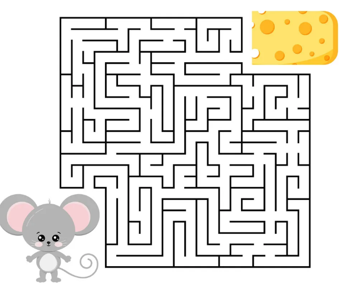

Figure 1: A framework for learning how to interact with the environment from experience

The mouse is the **agent**, and the maze is the **environment**. The mouse takes the **action** and choose which way it goes. Finally it can get the **reward**, ie. cheese in this case.

The goal is to maximise the future reward by policy. Usually the environment is modeled as a **Markov Decision Process** (MDP).

The tricky part is that the **reward** is time delayed, which is not delivered directly after every **action** (credit assignment problem).

- Dense vs. sparse rewards
- Sample efficiency

### Model-based Reinforcement Learning

- Markov Decision Process $P(s',s,a)$
  - Policy iteration $\pi _\theta (s,a)$
  - Value iteration $V(s)$
- Dynamic programming and Bellman optimality
  - Nonlinear dynamics
  - $\frac{dx}{dt} = f(x(t), u(t), t)dt$

### Model-free Reinforcement Learning

- Gradient-free
  - On-policy (SARSA)
  - Off-policy (Q-learning)
- Gradient-based
  - Policy gradient optimisation

### Deep Reinforcement Learning

Actor critic, Deep MPC, DQN, Deep policy network etc.

## Reinforcement learning in this paper

### Model set-up

$N$ agents

Strategy $s_i \in \{Spite, Social\}$

At each time t: only one outgoing link from $i$ to $j$ ($j \neq i$)

- temporal adjacency matrix $l^t_{ij} \in N \times N$
- interaction set $I^t_i = \{ l^t_{ij} \,\,\text{or}\,\, l^t_{ji}\}$

payoff $u^t_i (s_i, s_j)$

|  | Spite | Social |
| --- | --- | --- |
| Spite | 0,0 | b,c |
| Social | c,b | b+c, b+c |

### A simplified analytic model

**INITIALISE** the nodes in this network randomly;  
**WHILE** loop $<10^6$:  
**FOR EACH** $i$ **in** N  
form one link $l^t_{ij}$ by $L_i=\{l_{ij} | u^t_i (s_i, s_j) \geq u^t_i (s_i, s_k) \,\, \text{for all } k \in N \}$  
calculate $\overline{U^t_i}=\sum_{j\in I^t_i} u^t_i (s_i, s_j) / |I^t_i|$  
**IF** $B^t_i=\{ j \in I^t_i | \overline{U^t_j} \geq \overline{U^t_i}\}$ is nonempty:  
select random $j\in B^t_i$  
$s^{t+1}_i=s^t_j$;  
**ELSE**  
$s^{t+1}_i=s^t_i$;